# Notebook

## 📊 Projeto Final — Análise Socioeconômica e Desempenho no ENEM 2023

Este projeto tem como objetivo central **investigar como a renda e fatores sociodemográficos podem influenciar o desempenho dos participantes no ENEM 2023**, utilizando uma abordagem de análise de dados exploratória, estatística e visual.

### 🔍 Objetivos Gerais

- Explorar a relação entre **renda**, **variáveis sociodemográficas** e o **desempenho nas provas** do ENEM.
- Avaliar **desigualdades educacionais** com base nas diferentes variáveis selecionadas.
- Criar visualizações que evidenciem os principais padrões e correlações.

### 🗂️ Estrutura do Projeto

O projeto está dividido em cinco etapas principais:

#### 1. Projeto

- Definição de escopo e objetivos analíticos.
- Organização de pastas e planejamento dos dados.

#### 2. Limpeza

- Importação e tratamento dos microdados do ENEM 2023.
- Tradução de códigos, tratamento de ausentes e criação de variáveis derivadas.
- Exportação de base limpa (`enem_tratado.csv`).

#### 3. Análise

- Geração de estatísticas descritivas e análise por grupos (renda, escolaridade, etc.).
- Cálculo de correlações e identificação de padrões relevantes.

#### 4. Visualização

- Produção de gráficos explicativos (boxplots, histogramas, heatmaps, dispersões).
- Padronização de estilo visual e exportação das figuras.

#### 5. Apresentação

- Entrega deste relatório.

### 🧾 Documentação Complementar

- Dicionário de variáveis do ENEM 2023.
- Fontes utilizadas e metodologia de análise.
- Arquivos salvos: base tratada, gráficos e relatórios.
- Fonte: https://www.gov.br/inep/pt-br/acesso-a-informacao/dados-abertos/microdados/enem - Microdados do Enem 2023

> **Nota:** Este projeto busca promover uma análise crítica e orientada por dados sobre as desigualdades educacionais no Brasil, com base em evidências concretas extraídas do maior exame educacional do país.

### Importação das bibliotecas

### Carga do dataset csv para df

|  | NU_INSCRICAO | NU_ANO | TP_FAIXA_ETARIA | TP_SEXO | TP_ESTADO_CIVIL | TP_COR_RACA | TP_NACIONALIDADE | TP_ST_CONCLUSAO | TP_ANO_CONCLUIU | TP_ESCOLA | TP_ENSINO | IN_TREINEIRO | CO_MUNICIPIO_ESC | NO_MUNICIPIO_ESC | CO_UF_ESC | SG_UF_ESC | TP_DEPENDENCIA_ADM_ESC | TP_LOCALIZACAO_ESC | TP_SIT_FUNC_ESC | CO_MUNICIPIO_PROVA | NO_MUNICIPIO_PROVA | CO_UF_PROVA | SG_UF_PROVA | TP_PRESENCA_CN | TP_PRESENCA_CH | TP_PRESENCA_LC | TP_PRESENCA_MT | CO_PROVA_CN | CO_PROVA_CH | … |
| --- | --- | --- | --- | --- | --- | --- | --- | --- | --- | --- | --- | --- | --- | --- | --- | --- | --- | --- | --- | --- | --- | --- | --- | --- | --- | --- | --- | --- | --- | --- |
| 0 | 210059085136 | 2023 | 14 | M | 2 | 1 | 1 | 1 | 17 | 1 | NaN | 0 | NaN | NaN | NaN | NaN | NaN | NaN | NaN | 5300108 | Brasília | 53 | DF | 0 | 0 | 0 | 0 | NaN | NaN | … |
| 1 | 210059527735 | 2023 | 12 | M | 2 | 1 | 0 | 1 | 16 | 1 | NaN | 0 | NaN | NaN | NaN | NaN | NaN | NaN | NaN | 5300108 | Brasília | 53 | DF | 0 | 0 | 0 | 0 | NaN | NaN | … |
| 2 | 210061103945 | 2023 | 6 | F | 1 | 1 | 1 | 1 | 0 | 1 | NaN | 0 | NaN | NaN | NaN | NaN | NaN | NaN | NaN | 4305108 | Caxias do Sul | 43 | RS | 1 | 1 | 1 | 1 | 1221.00 | 1193.00 | … |
| 3 | 210060214087 | 2023 | 2 | F | 1 | 3 | 1 | 2 | 0 | 2 | 1.00 | 0 | 2304400.00 | Fortaleza | 23.00 | CE | 2.00 | 1.00 | 1.00 | 2304400 | Fortaleza | 23 | CE | 1 | 1 | 1 | 1 | 1224.00 | 1192.00 | … |
| 4 | 210059980948 | 2023 | 3 | F | 1 | 3 | 1 | 2 | 0 | 2 | 1.00 | 0 | 2311306.00 | Quixadá | 23.00 | CE | 2.00 | 1.00 | 1.00 | 2311306 | Quixadá | 23 | CE | 1 | 1 | 1 | 1 | 1222.00 | 1191.00 | … |

### Análise preliminar

```
(3933955, 76)
```

```
NU_INSCRICAO       0
NU_ANO             0
TP_FAIXA_ETARIA    0
TP_SEXO            0
TP_ESTADO_CIVIL    0
                  ..
Q021               0
Q022               0
Q023               0
Q024               0
Q025               0
Length: 76, dtype: int64
```

```
NU_NOTA_CN   31.56
NU_NOTA_CH   28.25
NU_NOTA_LC   28.25
NU_NOTA_MT   31.56
dtype: float64
```

```
(2678264, 76)
```

```
Index(['NU_INSCRICAO', 'NU_ANO', 'TP_FAIXA_ETARIA', 'TP_SEXO',
       'TP_ESTADO_CIVIL', 'TP_COR_RACA', 'TP_NACIONALIDADE', 'TP_ST_CONCLUSAO',
       'TP_ANO_CONCLUIU', 'TP_ESCOLA', 'TP_ENSINO', 'IN_TREINEIRO',
       'CO_MUNICIPIO_ESC', 'NO_MUNICIPIO_ESC', 'CO_UF_ESC', 'SG_UF_ESC',
       'TP_DEPENDENCIA_ADM_ESC', 'TP_LOCALIZACAO_ESC', 'TP_SIT_FUNC_ESC',
       'CO_MUNICIPIO_PROVA', 'NO_MUNICIPIO_PROVA', 'CO_UF_PROVA',
       'SG_UF_PROVA', 'TP_PRESENCA_CN', 'TP_PRESENCA_CH', 'TP_PRESENCA_LC',
       'TP_PRESENCA_MT', 'CO_PROVA_CN', 'CO_PROVA_CH', 'CO_PROVA_LC',
       'CO_PROVA_MT', 'NU_NOTA_CN', 'NU_NOTA_CH', 'NU_NOTA_LC', 'NU_NOTA_MT',
       'TX_RESPOSTAS_CN', 'TX_RESPOSTAS_CH', 'TX_RESPOSTAS_LC',
       'TX_RESPOSTAS_MT', 'TP_LINGUA', 'TX_GABARITO_CN', 'TX_GABARITO_CH',
       'TX_GABARITO_LC', 'TX_GABARITO_MT', 'TP_STATUS_REDACAO',
       'NU_NOTA_COMP1', 'NU_NOTA_COMP2', 'NU_NOTA_COMP3', 'NU_NOTA_COMP4',
       'NU_NOTA_COMP5', 'NU_NOTA_REDACAO', 'Q001', 'Q002', 'Q003', 'Q004',
       'Q005', 'Q006', 'Q007', 'Q008', 'Q009', 'Q010', 'Q011', 'Q012', 'Q013',
       'Q014', 'Q015', 'Q016', 'Q017', 'Q018', 'Q019', 'Q020', 'Q021', 'Q022',
       'Q023', 'Q024', 'Q025'],
      dtype='object')
```

### Tratamento e limpeza os dados

```
(2678264, 11)
```

```
Total de registros: 2678264
```

|  | faixa_etaria | sexo | estado_civil | cor_raca | tipo_escola | ciencia_natureza | ciencia_humanas | linguagens_codigos | matematica | redacao | renda |
| --- | --- | --- | --- | --- | --- | --- | --- | --- | --- | --- | --- |
| 2 | 21 anos | Feminino | Solteiro(a) | Branca | Não respondeu | 502.00 | 498.90 | 475.60 | 363.20 | 700.00 | De R$ 1.320,01 a R$ 1.980,00 |
| 3 | 17 anos | Feminino | Solteiro(a) | Parda | Pública | 459.00 | 508.50 | 507.20 | 466.70 | 880.00 | De R$ 1.320,01 a R$ 1.980,00 |
| 4 | 18 anos | Feminino | Solteiro(a) | Parda | Pública | 402.50 | 379.20 | 446.90 | 338.30 | 560.00 | Até R$ 1.320,00 |
| 9 | Entre 26 e 30 anos | Masculino | Solteiro(a) | Branca | Não respondeu | 564.70 | 630.30 | 610.40 | 680.20 | 600.00 | De R$ 3.300,01 a R$ 3.960,00 |
| 10 | 23 anos | Masculino | Solteiro(a) | Parda | Não respondeu | 644.90 | 620.20 | 626.90 | 736.30 | 860.00 | Até R$ 1.320,00 |

```
faixa_etaria           object
sexo                   object
estado_civil           object
cor_raca               object
tipo_escola            object
ciencia_natureza      float64
ciencia_humanas       float64
linguagens_codigos    float64
matematica            float64
redacao               float64
renda                  object
dtype: object
```

### Análise exploratória

#### Informações sociodemográficas

```
faixa_etaria
Menor de 17 anos      288516
17 anos               620798
18 anos               682826
19 anos               292330
20 anos               169359
21 anos               108734
22 anos                77814
23 anos                59721
24 anos                46689
25 anos                36110
Entre 26 e 30 anos    114427
Entre 31 e 35 anos     60221
Entre 36 e 40 anos     44935
Entre 41 e 45 anos     31616
Entre 46 e 50 anos     20130
Entre 51 e 55 anos     12350
Entre 56 e 60 anos      6974
Entre 61 e 65 anos      3038
Entre 66 e 70 anos      1194
Maior de 70 anos         482
Name: count, dtype: int64
```

```
sexo
Masculino    1034218
Feminino     1644046
Name: count, dtype: int64
```

```
estado_civil
Não informado                               104172
Solteiro(a)                                2441183
Casado(a)/Mora com companheiro(a)            96037
Divorciado(a)/Desquitado(a)/Separado(a)      34409
Viúvo(a)                                      2463
Name: count, dtype: int64
```

```
cor_raca
Não declarado                 33230
Branca                      1153783
Preta                        316996
Parda                       1117228
Amarela                       42674
Indígena                      14353
Não dispõe da informação          0
Name: count, dtype: int64
```

```
renda
Nenhuma Renda                       155599
Até R\$ 1.320,00                    779111
De R\$ 1.320,01 a R\$ 1.980,00      414445
De R\$ 1.980,01 a R\$ 2.640,00      295876
De R\$ 2.640,01 a R\$ 3.300,00      209516
De R\$ 3.300,01 a R\$ 3.960,00      127207
De R\$ 3.960,01 a R\$ 5.280,00      201713
De R\$ 5.280,01 a R\$ 6.600,00      110432
De R\$ 6.600,01 a R\$ 7.920,00       69432
De R\$ 7.920,01 a R\$ 9.240,00       61687
De R\$ 9.240,01 a R\$ 10.560,00      49297
De R\$ 10.560,01 a R\$ 11.880,00     32854
De R\$ 11.880,01 a R\$ 13.200,00     28081
De R\$ 13.200,01 a R\$ 15.840,00     34689
De R\$ 15.840,01 a R\$ 19.800,00     34496
De R\$ 19.800,01 a R\$ 26.400,00     31931
Acima de R\$ 26.400,00               41898
Name: count, dtype: int64
```

```
0.00       20
220.00      1
280.00      1
287.20      1
287.70      1
           ..
4237.70     1
4240.10     1
4240.70     1
4252.00     1
4312.90     1
Name: count, Length: 61976, dtype: int64
```

```
redacao
1000.00        59
980.00      12734
960.00      43363
940.00      68159
920.00      88182
900.00      73440
880.00      87412
860.00      63046
840.00      82741
820.00      61190
800.00      81615
780.00      59790
760.00      83072
740.00      60748
720.00      88256
700.00      68332
680.00      99584
660.00      78323
640.00     118965
620.00     101152
600.00     144461
580.00     118647
560.00     143610
540.00      99263
520.00     111722
500.00      70453
480.00      83565
460.00      53499
440.00      60695
420.00      34607
400.00      46522
380.00      30695
360.00      50635
340.00      29363
320.00      31859
300.00      16473
280.00      17331
260.00       7924
240.00       6942
220.00       2549
200.00       2036
180.00        744
160.00        587
140.00        169
120.00        204
100.00         65
80.00         128
60.00          90
40.00         114
0.00        93149
Name: count, dtype: int64
```

#### Estatísticas descritivas

|  | ciencia_natureza | ciencia_humanas | linguagens_codigos | matematica | redacao |
| --- | --- | --- | --- | --- | --- |
| count | 2678264.00 | 2678264.00 | 2678264.00 | 2678264.00 | 2678264.00 |
| mean | 495.91 | 526.20 | 520.30 | 534.03 | 626.60 |
| std | 87.78 | 86.81 | 74.12 | 131.53 | 209.03 |
| min | 0.00 | 0.00 | 0.00 | 0.00 | 0.00 |
| 25% | 440.60 | 471.20 | 473.70 | 431.40 | 520.00 |
| 50% | 494.00 | 532.90 | 524.90 | 523.80 | 620.00 |
| 75% | 551.30 | 586.90 | 571.80 | 630.30 | 780.00 |
| max | 868.40 | 823.00 | 820.80 | 958.60 | 1000.00 |

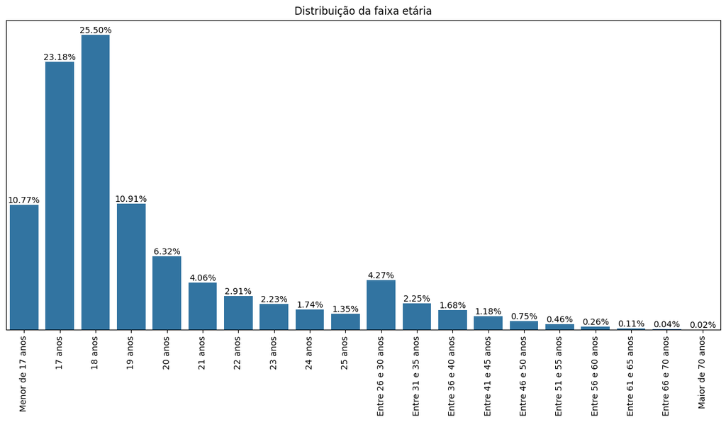

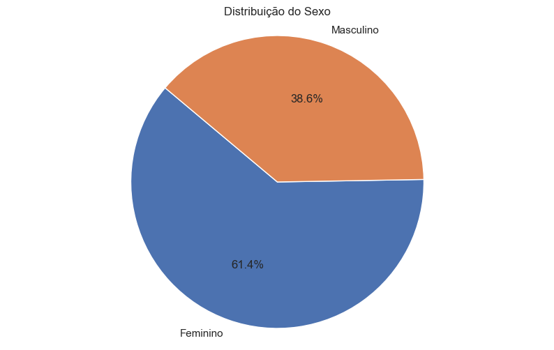

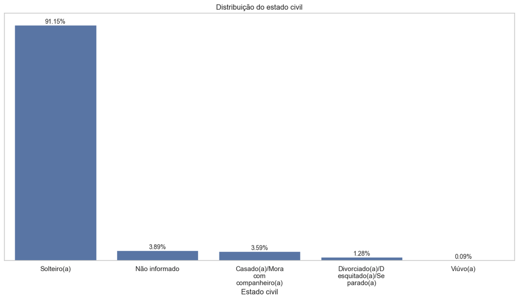

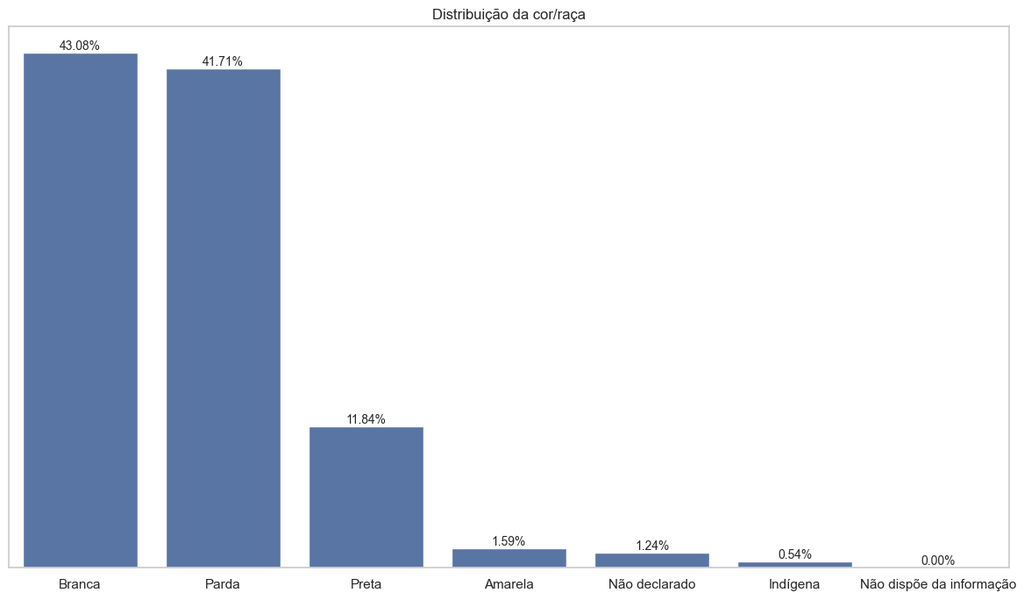

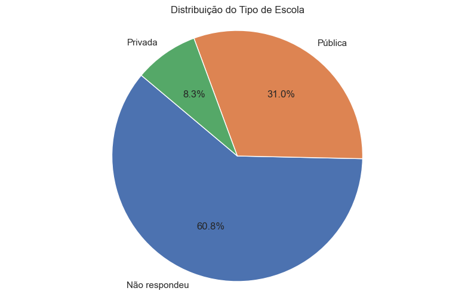

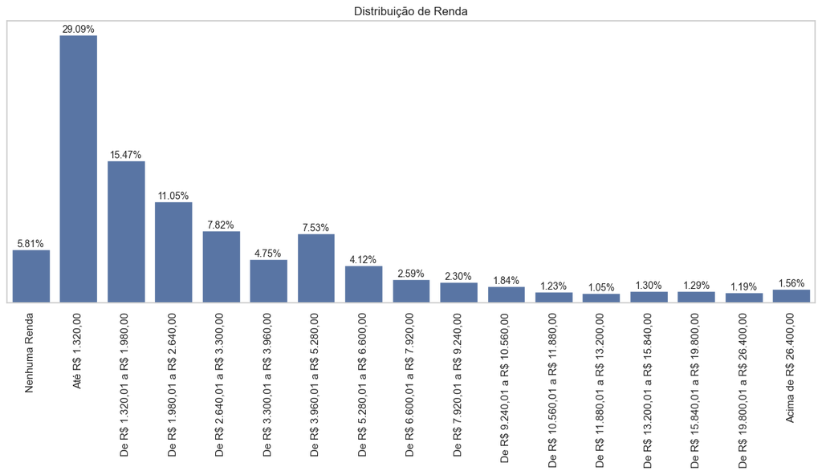

### Visualização dos dados

#### Distribuição e correlação das notas

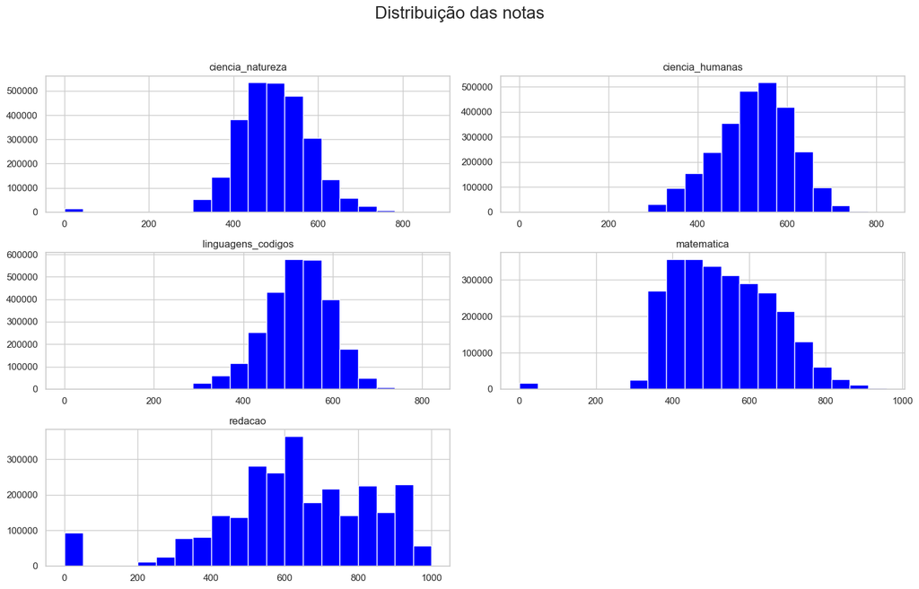

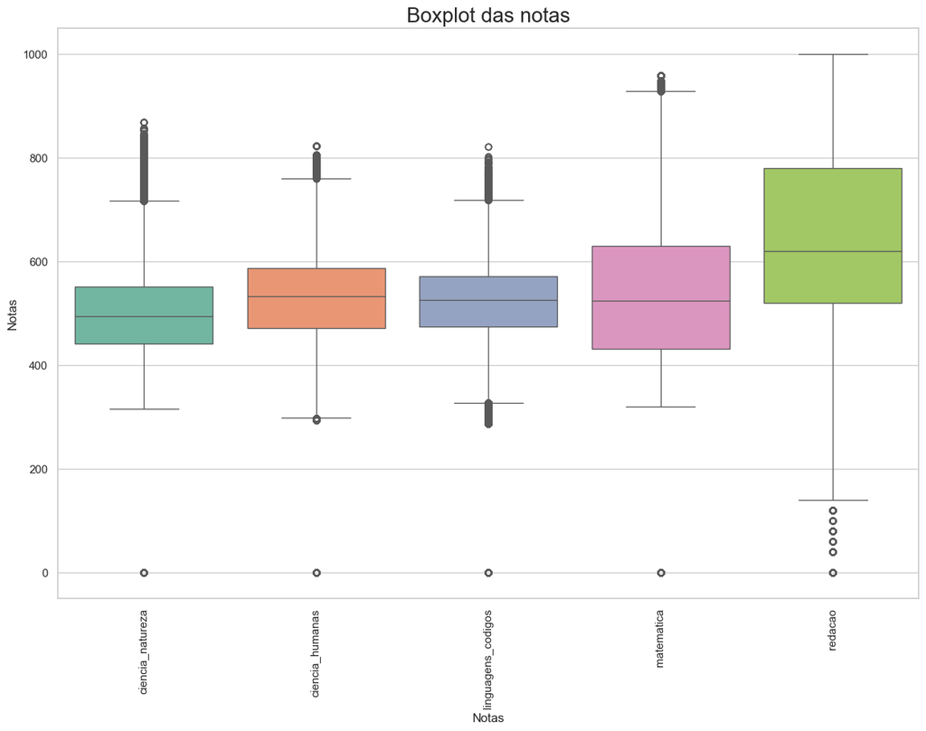

```
redacao              620.00
ciencia_humanas      532.90
linguagens_codigos   524.90
matematica           523.80
ciencia_natureza     494.00
dtype: float64
```

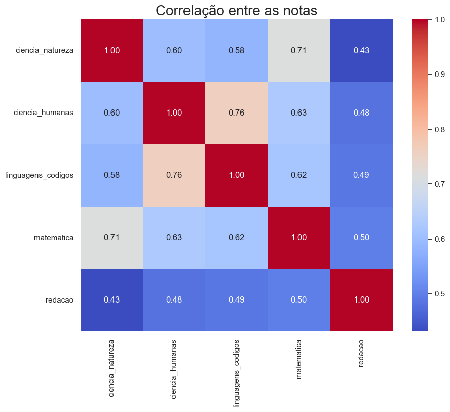

#### Verificação de normalidade das notas

```
Teste de Kolmogorov-Smirnov para ciencia_natureza:
Estatística KS: 0.0383, p-valor: 0.0000
A distribuição de ciencia_natureza não é normal (p-valor < 0.05)

Teste de Kolmogorov-Smirnov para ciencia_humanas:
Estatística KS: 0.0318, p-valor: 0.0000
A distribuição de ciencia_humanas não é normal (p-valor < 0.05)
```

```
Teste de Kolmogorov-Smirnov para linguagens_codigos:
Estatística KS: 0.0259, p-valor: 0.0000
A distribuição de linguagens_codigos não é normal (p-valor < 0.05)

Teste de Kolmogorov-Smirnov para matematica:
Estatística KS: 0.0531, p-valor: 0.0000
A distribuição de matematica não é normal (p-valor < 0.05)
```

```
Teste de Kolmogorov-Smirnov para redacao:
Estatística KS: 0.0659, p-valor: 0.0000
A distribuição de redacao não é normal (p-valor < 0.05)
```

```
Teste de Kruskal-Walllis para Matemática
Estatística H: 577483.11, p-valor: 0.0000
```

```
Teste de Kruskal-Walllis para Redação
Estatística H: 290043.63, p-valor: 0.0000
```

```
Teste de Kruskal-Walllis para Linguagens e Códigos
Estatística H: 430587.27, p-valor: 0.0000
```

```
Teste de Kruskal-Walllis para Ciências da Natureza
Estatística H: 431723.56, p-valor: 0.0000
```

```
Teste de Kruskal-Walllis para Ciências Humanas
Estatística H: 421464.35, p-valor: 0.0000
```

#### Análise entre Renda e Notas

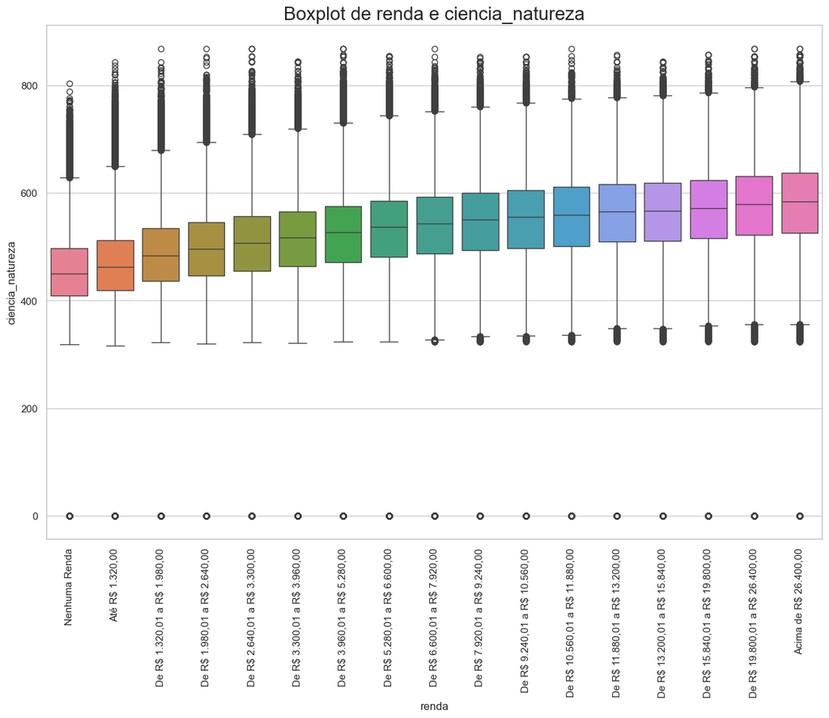

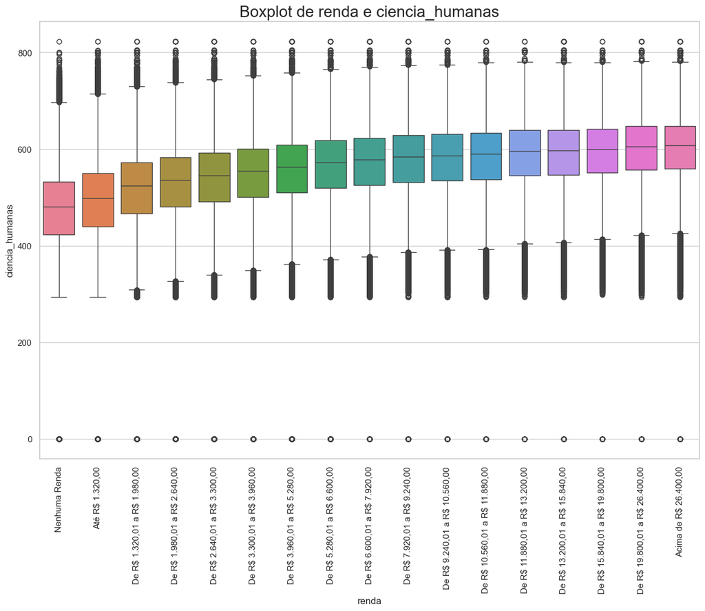

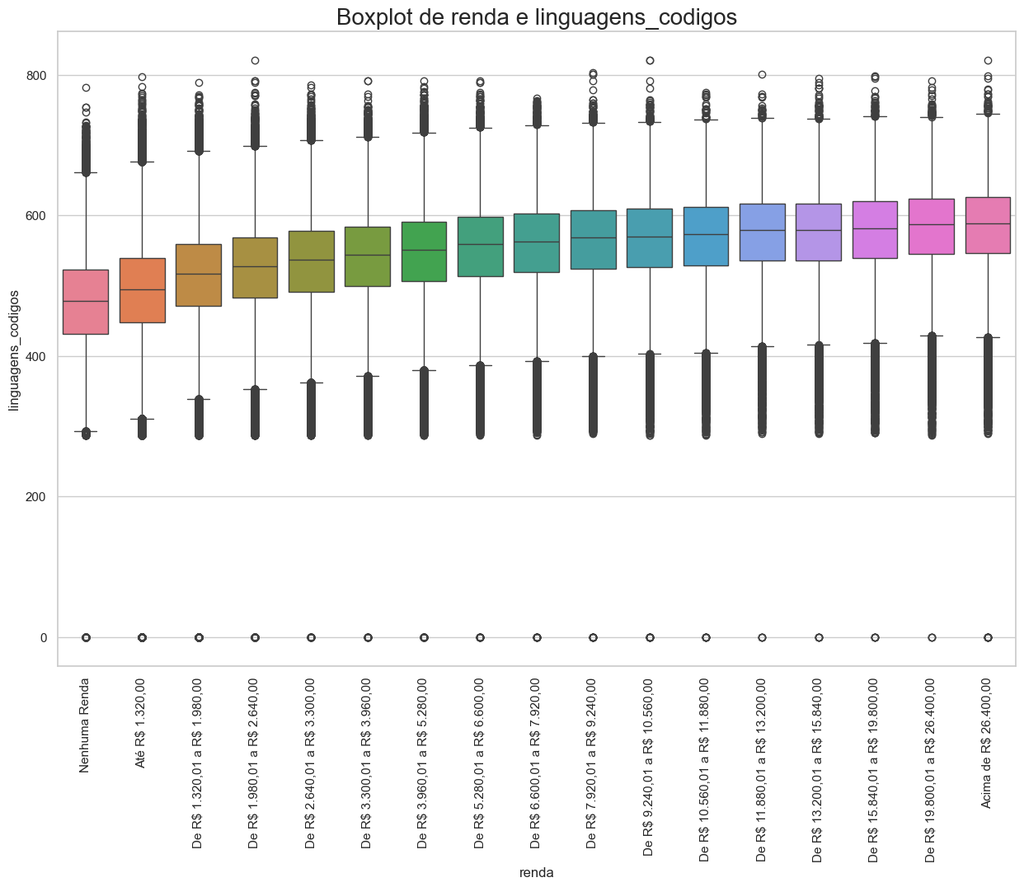

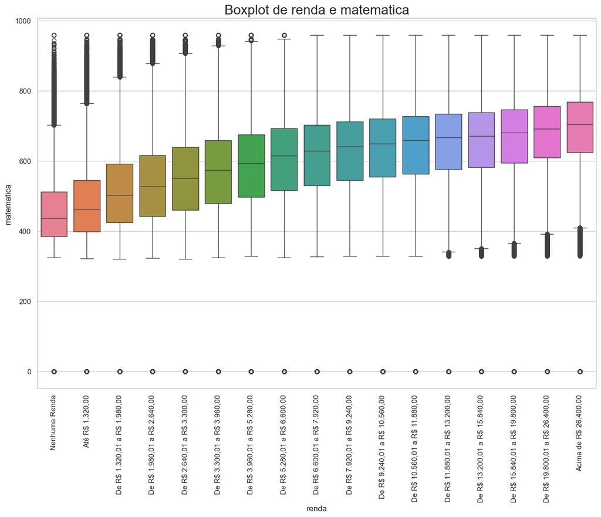

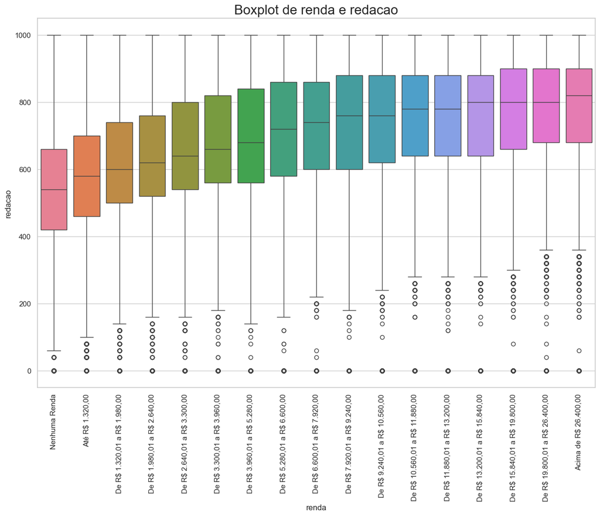

#### Análise Renda e Cor

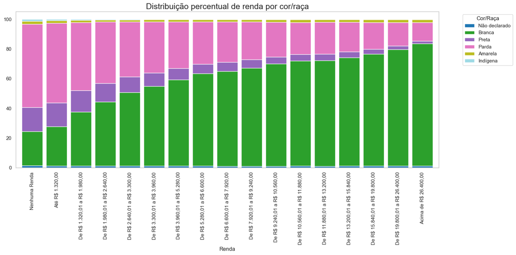

#### Regressão linear - Variáveis importantes para obter uma boa nota em Matemática

**Disclaimer:** lembre-se que estamos considerando apenas as variáveis categóricas que definimos no nosso dataset. Existem outras variáveis que poderiam ser analisadas, como esforço, horas de estudo, entre outras. Além disso, o ENEM é uma prova que avalia o conhecimento dos alunos em diversas áreas e não deve ser visto como um único indicador de desempenho ou capacidade. A análise aqui apresentada é apenas uma visão geral e não deve ser usada para tirar conclusões definitivas sobre os alunos ou suas habilidades.

```
R²: 0.6345
MSE: 6320.18
renda_Acima de R\$ 26.400,00             59.79
renda_De R\$ 19.800,01 a R\$ 26.400,00   54.13
renda_De R\$ 15.840,01 a R\$ 19.800,00   50.30
renda_De R\$ 13.200,01 a R\$ 15.840,00   47.57
renda_De R\$ 11.880,01 a R\$ 13.200,00   45.51
renda_De R\$ 10.560,01 a R\$ 11.880,00   43.74
renda_De R\$ 9.240,01 a R\$ 10.560,00    41.13
renda_De R\$ 7.920,01 a R\$ 9.240,00     38.58
renda_De R\$ 6.600,01 a R\$ 7.920,00     35.88
renda_De R\$ 5.280,01 a R\$ 6.600,00     32.78
dtype: float64
```

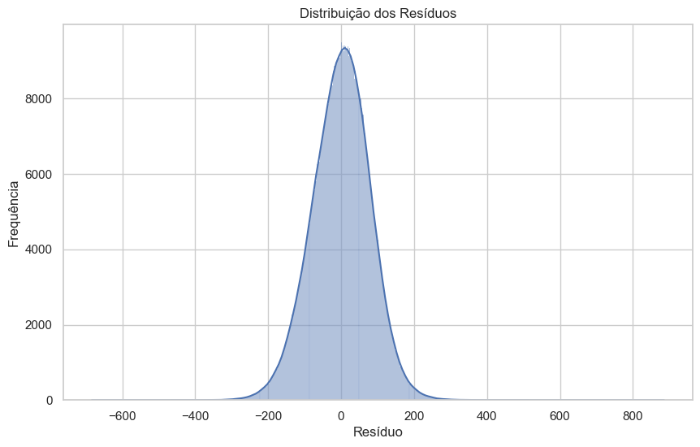

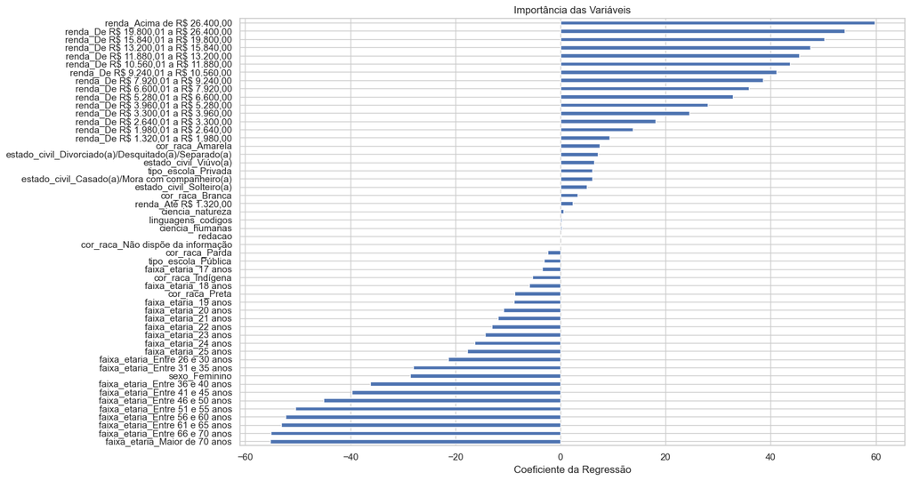

#### Regressão linear - Variáveis importantes para obter uma boa nota em Redação

**Disclaimer:** lembre-se que estamos considerando apenas as variáveis categóricas que definimos no nosso dataset. Existem outras variáveis que poderiam ser analisadas, como esforço, horas de estudo, entre outras. Além disso, o ENEM é uma prova que avalia o conhecimento dos alunos em diversas áreas e não deve ser visto como um único indicador de desempenho ou capacidade. A análise aqui apresentada é apenas uma visão geral e não deve ser usada para tirar conclusões definitivas sobre os alunos ou suas habilidades.

```
R²: 0.3684
MSE: 27580.28
sexo_Feminino                            70.79
tipo_escola_Privada                      35.30
renda_De R\$ 13.200,01 a R\$ 15.840,00   31.98
renda_De R\$ 15.840,01 a R\$ 19.800,00   31.88
renda_De R\$ 10.560,01 a R\$ 11.880,00   31.70
renda_De R\$ 11.880,01 a R\$ 13.200,00   30.94
renda_De R\$ 9.240,01 a R\$ 10.560,00    30.85
renda_De R\$ 7.920,01 a R\$ 9.240,00     30.11
renda_De R\$ 19.800,01 a R\$ 26.400,00   29.22
renda_De R\$ 6.600,01 a R\$ 7.920,00     29.00
dtype: float64
```

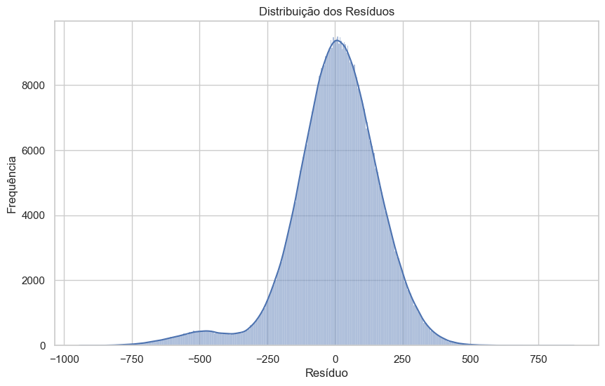

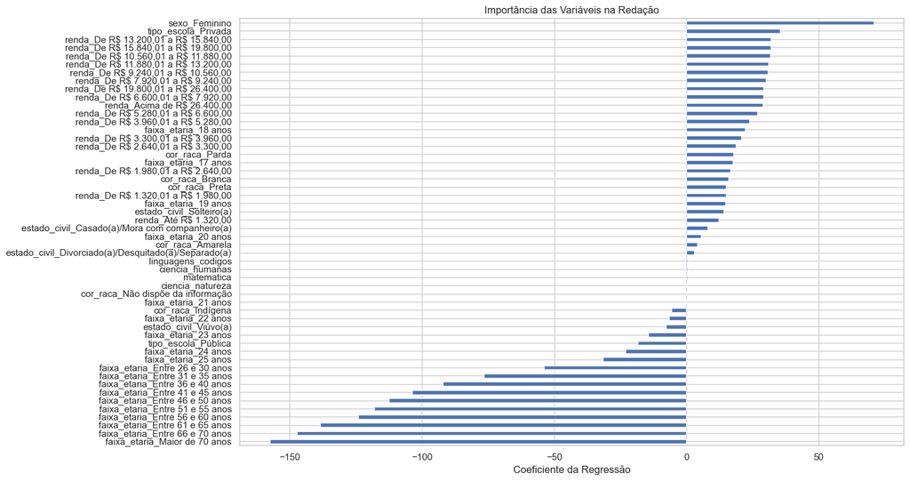

#### Regressão linear - Variáveis importantes para obter uma boa nota em Ciências Humanas

**Disclaimer:** lembre-se que estamos considerando apenas as variáveis categóricas que definimos no nosso dataset. Existem outras variáveis que poderiam ser analisadas, como esforço, horas de estudo, entre outras. Além disso, o ENEM é uma prova que avalia o conhecimento dos alunos em diversas áreas e não deve ser visto como um único indicador de desempenho ou capacidade. A análise aqui apresentada é apenas uma visão geral e não deve ser usada para tirar conclusões definitivas sobre os alunos ou suas habilidades.

```
R²: 0.6374
MSE: 2734.44
faixa_etaria_Entre 61 e 65 anos   30.24
faixa_etaria_Entre 56 e 60 anos   27.08
faixa_etaria_Entre 51 e 55 anos   25.83
faixa_etaria_Entre 41 e 45 anos   24.70
faixa_etaria_Entre 46 e 50 anos   24.53
faixa_etaria_Entre 66 e 70 anos   24.50
faixa_etaria_Entre 36 e 40 anos   24.30
faixa_etaria_Entre 31 e 35 anos   22.07
faixa_etaria_Maior de 70 anos     20.74
faixa_etaria_Entre 26 e 30 anos   16.78
dtype: float64
```

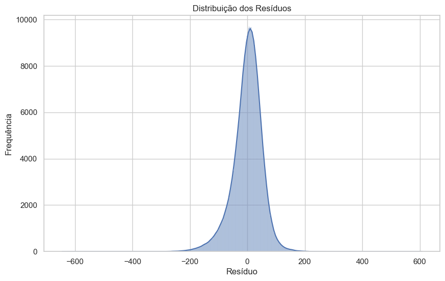

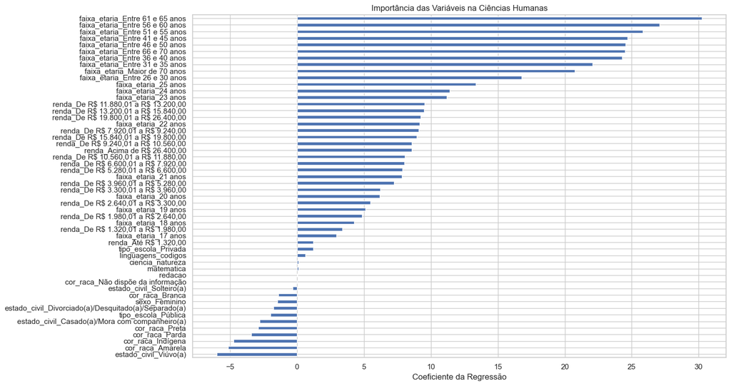

#### Regressão linear - Variáveis importantes para obter uma boa nota em Ciências da Natureza

**Disclaimer:** lembre-se que estamos considerando apenas as variáveis categóricas que definimos no nosso dataset. Existem outras variáveis que poderiam ser analisadas, como esforço, horas de estudo, entre outras. Além disso, o ENEM é uma prova que avalia o conhecimento dos alunos em diversas áreas e não deve ser visto como um único indicador de desempenho ou capacidade. A análise aqui apresentada é apenas uma visão geral e não deve ser usada para tirar conclusões definitivas sobre os alunos ou suas habilidades.

```
R²: 0.5635
MSE: 3362.18
faixa_etaria_Maior de 70 anos     43.24
faixa_etaria_Entre 66 e 70 anos   35.96
faixa_etaria_Entre 56 e 60 anos   35.58
faixa_etaria_Entre 61 e 65 anos   34.03
faixa_etaria_Entre 51 e 55 anos   33.63
faixa_etaria_Entre 46 e 50 anos   33.49
faixa_etaria_Entre 41 e 45 anos   30.81
faixa_etaria_Entre 36 e 40 anos   29.70
faixa_etaria_Entre 31 e 35 anos   25.06
faixa_etaria_Entre 26 e 30 anos   21.61
dtype: float64
```

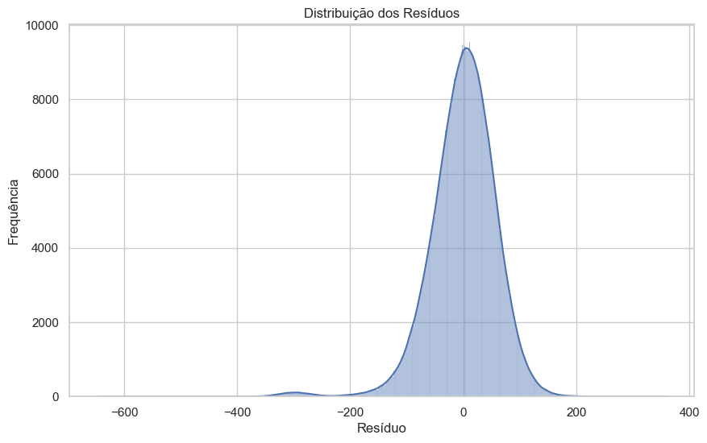

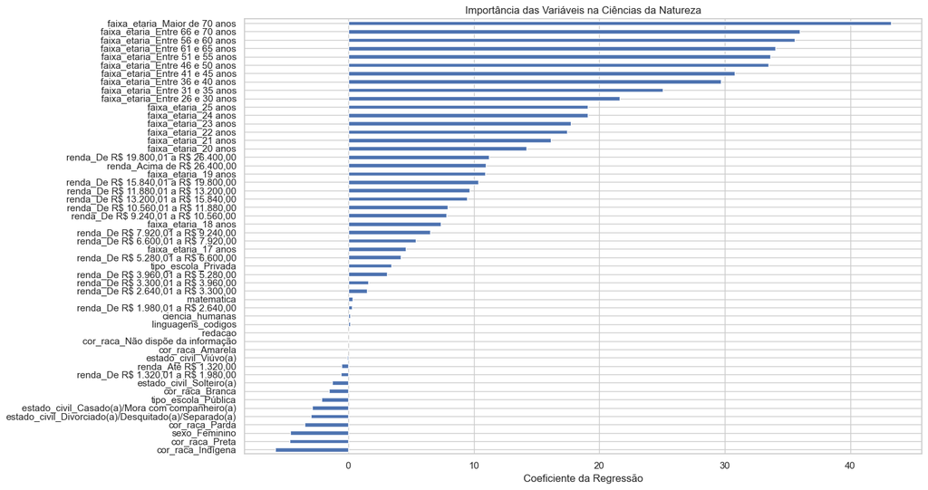

#### Regressão linear - Variáveis importantes para obter uma boa nota em Linguagens e Códigos

**Disclaimer:** lembre-se que estamos considerando apenas as variáveis categóricas que definimos no nosso dataset. Existem outras variáveis que poderiam ser analisadas, como esforço, horas de estudo, entre outras. Além disso, o ENEM é uma prova que avalia o conhecimento dos alunos em diversas áreas e não deve ser visto como um único indicador de desempenho ou capacidade. A análise aqui apresentada é apenas uma visão geral e não deve ser usada para tirar conclusões definitivas sobre os alunos ou suas habilidades.

```
R²: 0.6294
MSE: 2036.26
renda_De R\$ 19.800,01 a R\$ 26.400,00   14.74
renda_De R\$ 11.880,01 a R\$ 13.200,00   14.62
renda_De R\$ 15.840,01 a R\$ 19.800,00   14.32
renda_De R\$ 10.560,01 a R\$ 11.880,00   14.05
renda_De R\$ 6.600,01 a R\$ 7.920,00     14.03
renda_De R\$ 7.920,01 a R\$ 9.240,00     14.00
renda_Acima de R\$ 26.400,00             13.93
renda_De R\$ 13.200,01 a R\$ 15.840,00   13.90
renda_De R\$ 5.280,01 a R\$ 6.600,00     13.86
renda_De R\$ 3.960,01 a R\$ 5.280,00     13.52
dtype: float64
```

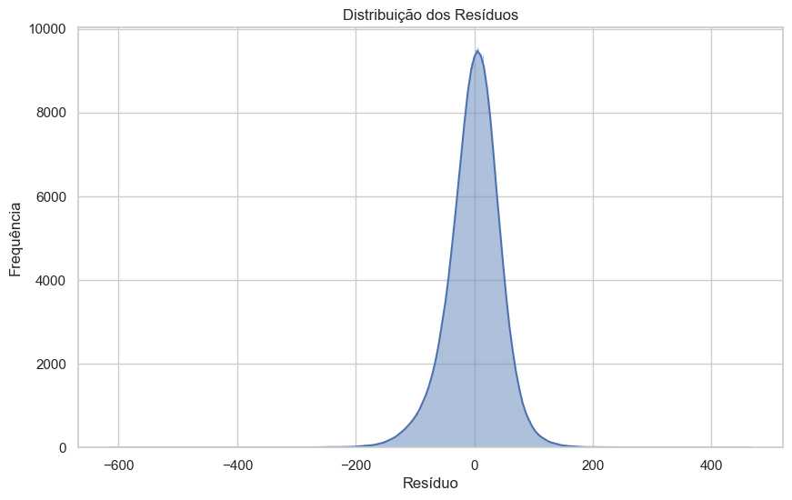

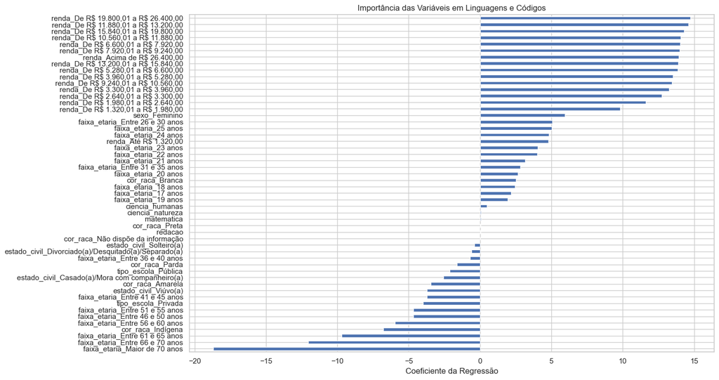